# 00-exploration_data

Source: [`vignettes/00-exploration_data.Rmd`](https://github.com/inrae/diades.atlas/blob/HEAD/vignettes/00-exploration_data.Rmd)

# 00-exploration-of-data

### Installation

Install the present package and use its core functions

```r
remotes::install_github('inrae/diades.atlas')
```

### Packages

```r
library(dplyr)
library(DBI)
library(ggplot2)
library(RPostgres)
library(diades.atlas)
# pkgload::load_all()
```

**You can use this package without opening the Shiny application**

### Connect to the database

```r
se <- new.env()

conn_eurodiad <- dbConnect(
  RPostgres::Postgres(),
  dbname = 'eurodiad',
  host = '<your-host>',
  port = 5432,
  user = '<your-username>',
  password = rstudioapi::askForPassword("Database password"))

session$userData$con <-conn_eurodiad
```

```r
# For ThinkR only
se <- new.env()
conn_eurodiad <- connect(session = se)
DBI::dbListTables(conn_eurodiad)
```

```
##  [1] "abundance_level"
##  [2] "basin"
##  [3] "basin_outlet"
##  [4] "casestudy_basin"
##  [5] "category"
##  [6] "cices"
##  [7] "climatic_model"
##  [8] "hydiadparameter"
##  [9] "ices_area"
## [10] "ices_grass"
## [11] "ices_rectangle"
## [12] "iucn_classification"
## [13] "iucn_level"
## [14] "lang85_85"
## [15] "species"
```

[output cut: 21 more lines]

### Explore data

It is recommended to use `tbl()` instead of `dbGetQuery()` to connect to a table in the database.  
`tbl()` does not download the table, it only connect to the database and let it run the query. This means that if you run a `filter()` or a `mutate()` after that, the database executes it, not R, which is more efficient.  
However, at some point, some of your {tidyverse} operations can not be realised or translated in SQL, hence, you need to download the resulting dataset using `collect()`. Then you can continue as usual.

For instance.

- `dbGetQuery()` download data in R
  - `filter()` is executed by R in your R session

```r
# Create a function
get_data_dbi <- function(conn_eurodiad, species_id, scenario) {
  query <- "SELECT * FROM diadesatlas.v_hybrid_model"

  dbGetQuery(conn_eurodiad, query) %>%
    filter(species_id %in% !!species_id,
           climatic_scenario %in% !!scenario)
}

# Use it
get_data_dbi(conn_eurodiad,
             species_id = c(6),
             scenario = 'rcp85')
```

```
##    hybrid_model_result_id basin_id
## 1                 1395745        1
## 2                 1395746        1
## 3                 1395747        1
## 4                 1395748        1
## 5                 1395749        1
## 6                 1395750        1
## 7                 1395751        1
## 8                 1395752        1
## 9                 1395753        1
## 10                1395754        1
## 11                1395755        1
## 12                1395756        1
## 13                1395757        1
## 14                1395758        1
```

[output cut: 399 more lines]

- `tbl()` only connects to the table, only a glimpse of the data is presented
  - `filter()` is run by the SQL database

```r
get_data_tbl <- function(conn_eurodiad, species_id, scenario) {
  tbl(conn_eurodiad, "v_hybrid_model") %>%
    filter(species_id %in% !!species_id,
           climatic_scenario %in% !!scenario)
}

# Use it
get_data_tbl(conn_eurodiad,
             species_id = c(6),
             scenario = 'rcp85')
```

```
## # Source:   lazy query [?? x 17]
## # Database: postgres
## #   [diadesatlas_owner@localhost:5432/diades]
##    hybrid_model_result_id basin_id species_id
##                     <int>    <int>      <int>
##  1                1395745        1          6
##  2                1395746        1          6
##  3                1395747        1          6
##  4                1395748        1          6
##  5                1395749        1          6
##  6                1395750        1          6
##  7                1395751        1          6
##  8                1395752        1          6
##  9                1395753        1          6
## 10                1395754        1          6
## # … with more rows, and 14 more variables:
## #   climatic_model_id <int>, year <int>,
## #   nit <dbl>, hsi <dbl>,
## #   saturation_rate <dbl>,
## #   climatic_scenario <chr>,
## #   climatic_model_code <chr>,
## #   oceanic_model <chr>, …
```

- If you need to create some {ggplot2} figures after that, you can collect

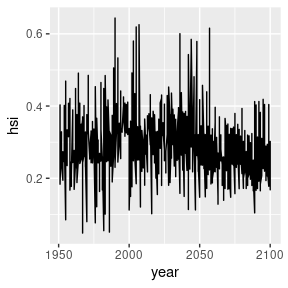

```r
get_data_tbl_collect <- function(conn_eurodiad, species_id, scenario) {
  tbl(conn_eurodiad, "v_hybrid_model") %>%
    filter(species_id %in% !!species_id,
           climatic_scenario %in% !!scenario) %>%
    # From collect(), the full data is in the R session
    collect()
}

# Use it
get_data_tbl_collect(conn_eurodiad,
                     species_id = c(6),
                     scenario = 'rcp85') %>%
  filter(basin_id == 1) %>%
  ggplot(aes(x = year)) +
  geom_line(aes(y = hsi))
```

- Note that you can use a full SQL query with `tbl()`

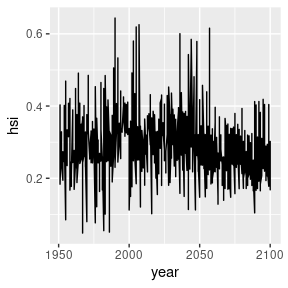

```r
get_data_tbl_query_collect <- function(conn_eurodiad, species_id, scenario) {
  query <- "SELECT * FROM diadesatlas.v_hybrid_model"

  tbl(conn_eurodiad, sql(query)) %>%
    # Adds a filter to be run as SQL in the database
    filter(species_id %in% !!species_id,
           climatic_scenario %in% !!scenario) %>%
    # From collect(), the full data is in the R session
    collect()
}

# Use it
get_data_tbl_query_collect(conn_eurodiad,
                           species_id = c(6),
                           scenario = 'rcp85') %>%
  filter(basin_id == 1) %>%
  ggplot(aes(x = year)) +
  geom_line(aes(y = hsi))
```

## Example with models

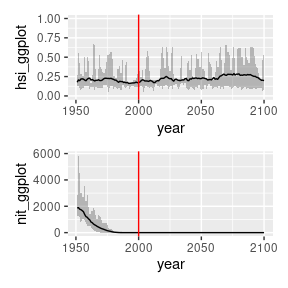

```r
# load data included in `get_hybrid_model()`
# debugonce(get_hybrid_model)
model_res <- get_hybrid_model(species_id = c(6), scenario = 'rcp85', lg = "fr", session = se)

plot_hsi_nit(model_res, selected_year = 2000, selected_bv = c(14), withNitStandardisation = FALSE)
```

### Disconnect from the database

```r
DBI::dbDisconnect(conn_eurodiad)
```